# 6 - Plots

Joseph Rickert

Wednesday, August 20, 2014

## Basic R Graphics

First, let’s look at some simple scatter plots. The Duncan data frame has 45 rows and 4 columns. Data on the prestige and other characteristics of 45 U. S. occupations in 1950.

```r
library(car)    # Load the library containing the sample data
class(Duncan)       # What kind of data structure is Duncan?
```

```
## [1] "data.frame"
```

```r
dim(Duncan)         # How big is Duncan?
```

```
## [1] 45  4
```

```r
Duncan[1:5,]        # Look at the first five rows of the data frame
```

```
##            type income education prestige
## accountant prof     62        86       82
## pilot      prof     72        76       83
## architect  prof     75        92       90
## author     prof     55        90       76
## chemist    prof     64        86       90
```

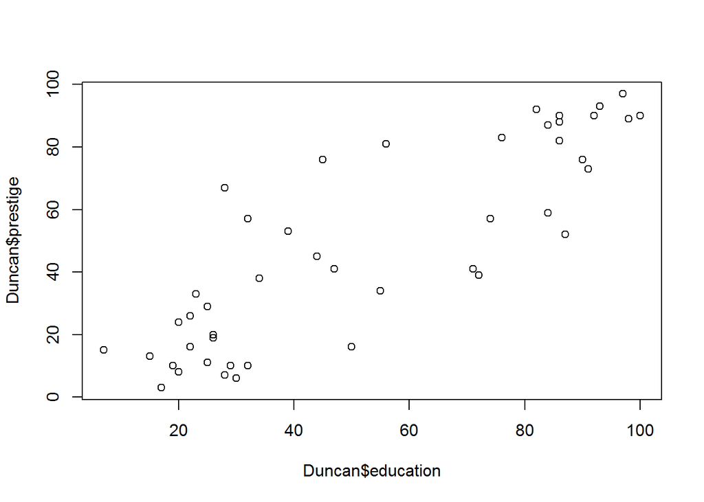

```r
plot(Duncan$education,Duncan$prestige)
```

Now, here is a truly ugly scatter plot. As an exercise, play with the parameters to creating something that is more pleasing to the eye. Here are a few web pages that you may find helpful. http://www.statmethods.net/advgraphs/parameters.html http://www.statmethods.net/graphs/scatterplot.html http://students.washington.edu/mclarkso/documents/line%20styles%20Ver2.pdf

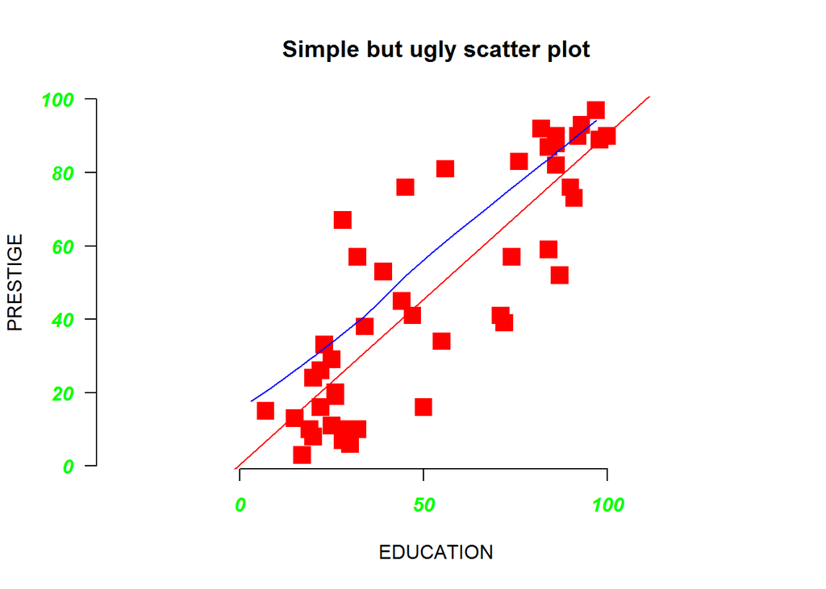

```r
attach(Duncan)      # make variables in data frame available in environment
#
plot(education,prestige,
   main="Simple but ugly scatter plot", #add a title
     col="red",                  # Change the color of thepoints
     pch=15,                     # Change the symbol to plot
   cex=2,                      # Change size of plotting symbol
   xlab="EDUCATION",               # Add a label on the x-axis
     ylab="PRESTIGE",            # Add a label on the y-axis
     bty="n",                    # Remove the box around the plot
     asp=1,                      # Change the y/x aspect ratio see help(plot)
     font.axis=4,                # Change axis font to bold italic
     col.axis="green",           # Change axia color to green
     las=1)                      # Make axis labels parallel to x-axis
abline(lm(prestige~education), col="red") # regression line (y~x)
lines(lowess(prestige,education), col="blue") # lowess line (y~x)
```

```r
help(par)
```

```
## starting httpd help server ... done
```

Here is a nice example of putting multiple plots on a grid.

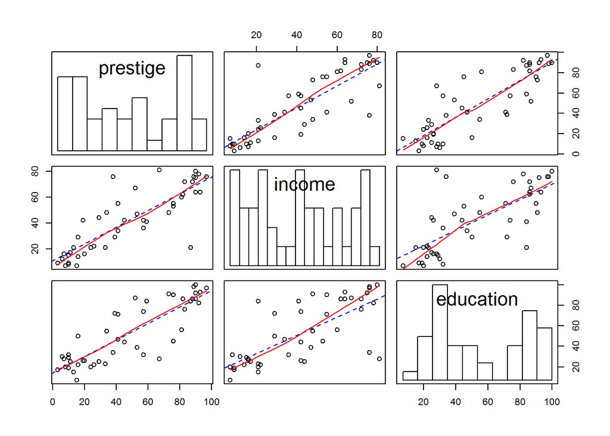

```r
# Build more complicated scatter plots
pairs(cbind(prestige,income,education),     # pairs is function that produces a maatrix of scatter plots
    panel=function(x,y){                    # define a function panel for the content of the matrix
        points(x,y)                         # plot the points
        abline(lm(y~x), lty=2,col="blue")   # add a linear regression
        lines(lowess(x,y),col="red")        # add a nonlinear regression
        },
    diag.panel=function(x){                 # define a new panel for the diagonals
        par(new=T)
        hist(x,main="",axes=F,nclass=12)    # put a histogram on each diagonal
        }
)
```

Here are a few more basic plots: - a simple histogram - a histogram with normal curve - a boxplot - kernel density plot

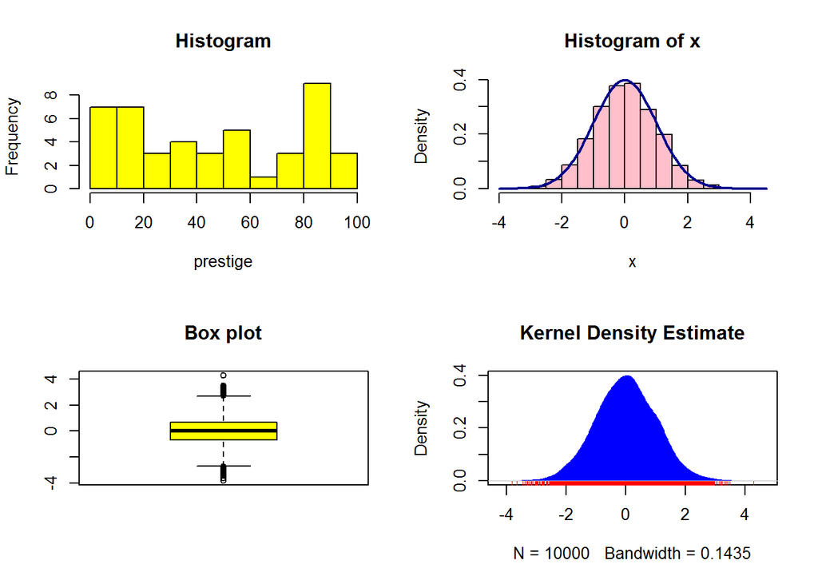

```r
par(mfrow=c(2,2))                       # set up to draw multiple plots on the same chart
# basic histogram
hist(Duncan$prestige,xlab="prestige",col = "yellow",main="Histogram")
#
x <- rnorm(10000)                           # random draw from normal distribution
                              # plot histogram
hist(x, freq = FALSE, col = "pink")
curve(dnorm,                                  # plot normal density
      col = "dark blue",                # set coor of curve
      lwd=2,                                    # fill in the area under the curve
      add = TRUE)                             # add curve to existing plot
#
boxplot(x,                                  # draw a boxplot
        col="yellow",
        main="Box plot")
#
plot(density(x),                            # plot a kernel density estimate
     col="blue",                              # set the color
     type="h",                                # fill in the curve
     main="Kernel Density Estimate")        # add a title
rug(x,col="red")
```

# Lattice (trellis) Graphics

Lattice graphics are the second major plotting system in R. Plots built with lattice have a very distinctive look, but the real value is the ease of making trellis plots - graphs that display a variable conditioned on an other variable. Some useful websites are: http://www.statmethods.net/advgraphs/trellis.html http://user2007.org/program/presentations/sarkar.pdf

## Lattice Histograms

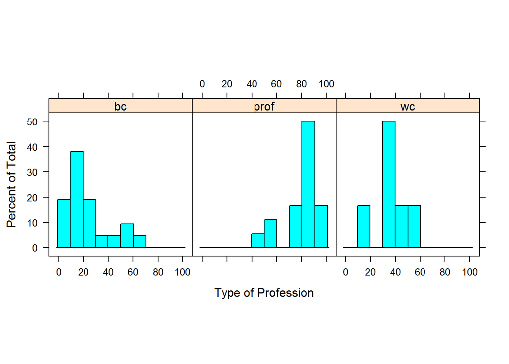

```r
# Basic histogram
histogram( ~ prestige | type,           # Formula to plot variable by a factor
             data = Duncan,                 # Data set is an input
             nint=10,
             layout = c(3,1),
             aspect = 1,
             xlab = "Type of Profession")
```

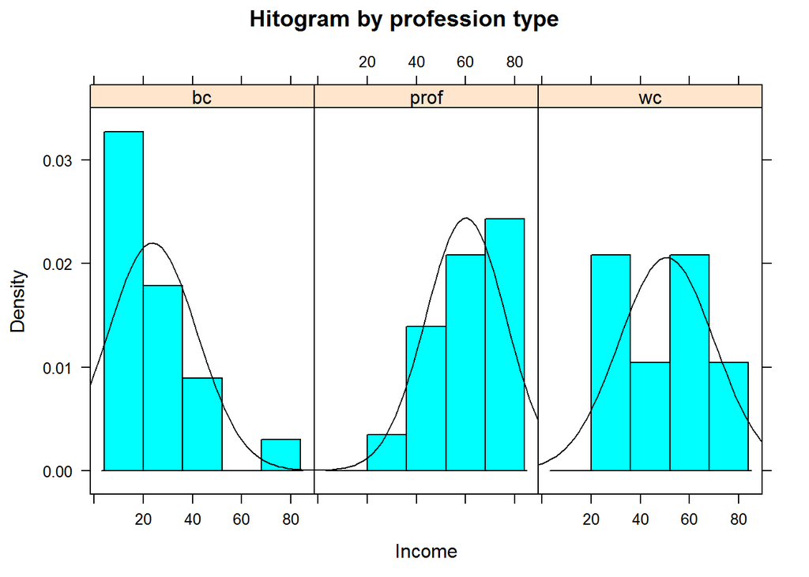

```r
histogram( ~ income | type,
           data = Duncan,
           nint=5,
           xlab = "Income",
           main= "Hitogram by profession type",
           type = "density",
           panel = function(x, ...) {
              panel.histogram(x, ...)
              panel.mathdensity(dmath = dnorm, col = "black",
                                args = list(mean=mean(x),sd=sd(x)))
          } )
```

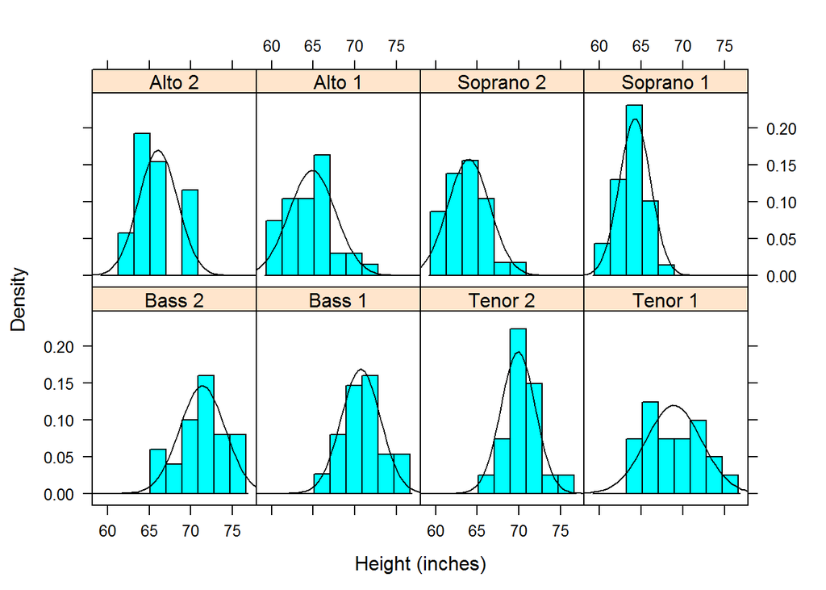

```r
#
# More histograms
# using singer data
histogram( ~ height | voice.part, data = singer,
          xlab = "Height (inches)", type = "density",
          panel = function(x, ...) {
              panel.histogram(x, ...)
              panel.mathdensity(dmath = dnorm, col = "black",
                                args = list(mean=mean(x),sd=sd(x)))
          } )
```

## Lattice Density plots

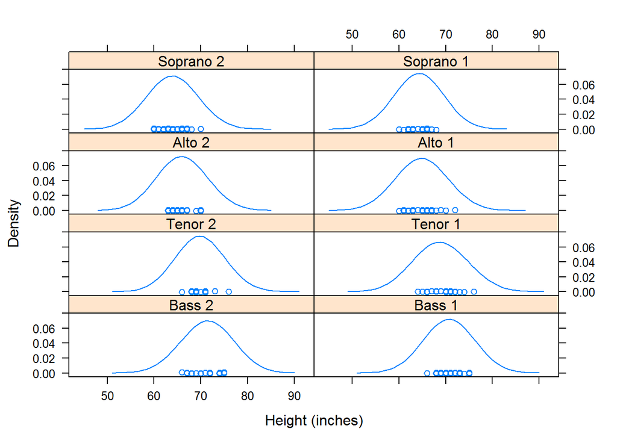

```r
densityplot( ~ height | voice.part, data = singer, layout = c(2, 4),
            xlab = "Height (inches)", bw = 5)
```

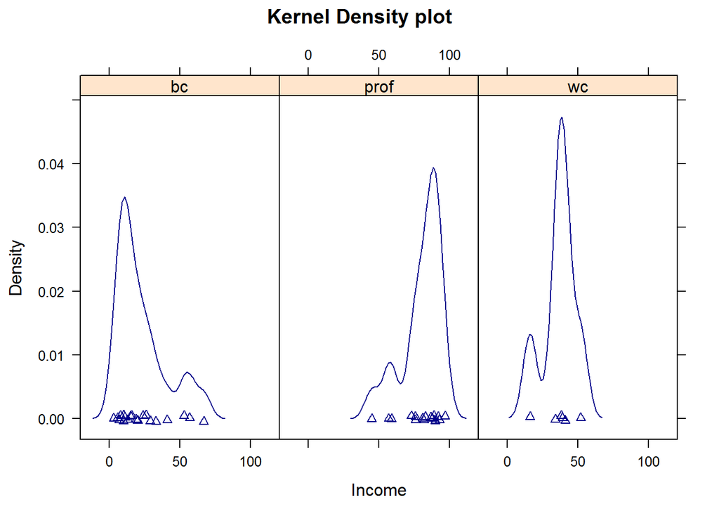

```r
# Kernel density plot
densityplot( ~ prestige | type,
            data = Duncan, layout = c(3,1),
            xlab = "Income",
            main= "Kernel Density plot",
            bw = 5,                 # bandwidth parameter
            col="dark blue",        # color
            pch=2                   # shape of plot symbol
            )
```

## Lattice Level Plots

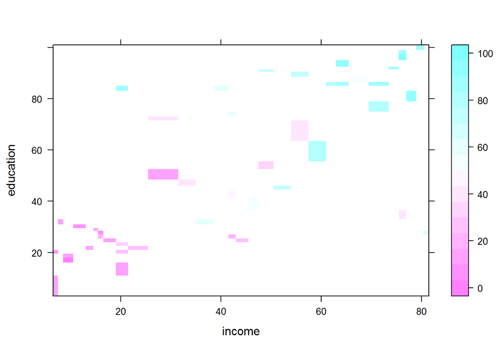

```r
# Level plot
levelplot(prestige ~ income*education,
       cuts = 15,
       groups =  ,
       data = Duncan,
       main = " ",
       sub = " ",
       xlab = "income",
       ylab = "education",
       colorkey = TRUE,
       contour = TRUE,
       #layout = c(1, 1),
       #xlim = c(, max(x)),
       #ylim = c(min(y), max(y)),
       )
```

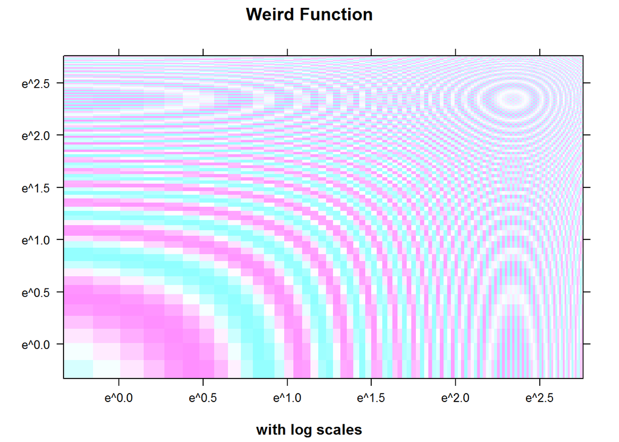

```r
#
# Fancy Level plot
x <- seq(pi/4, 5 * pi, length.out = 100)
y <- seq(pi/4, 5 * pi, length.out = 100)
r <- as.vector(sqrt(outer(x^2, y^2, "+")))
grid <- expand.grid(x=x, y=y)
grid$z <- cos(r^2) * exp(-r/(pi^3))
levelplot(z~x*y, grid, cuts = 50, scales=list(log="e"), xlab="",
          ylab="", main="Weird Function", sub="with log scales",
          colorkey = FALSE, region = TRUE)
```

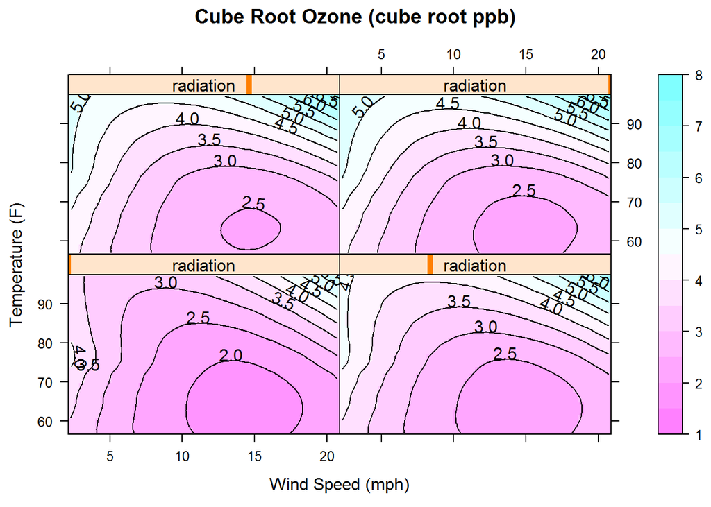

```r
#
# Another level plot
attach(environmental)
ozo.m <- loess((ozone^(1/3)) ~ wind * temperature * radiation,
       parametric = c("radiation", "wind"), span = 1, degree = 2)
w.marginal <- seq(min(wind), max(wind), length.out = 50)
t.marginal <- seq(min(temperature), max(temperature), length.out = 50)
r.marginal <- seq(min(radiation), max(radiation), length.out = 4)
wtr.marginal <- list(wind = w.marginal, temperature = t.marginal,
        radiation = r.marginal)
grid <- expand.grid(wtr.marginal)
grid[, "fit"] <- c(predict(ozo.m, grid))
contourplot(fit ~ wind * temperature | radiation, data = grid,
            cuts = 10, region = TRUE,
            xlab = "Wind Speed (mph)",
            ylab = "Temperature (F)",
            main = "Cube Root Ozone (cube root ppb)")
```

```r
detach()
```

## Some Miscellaneous Lattice Plots

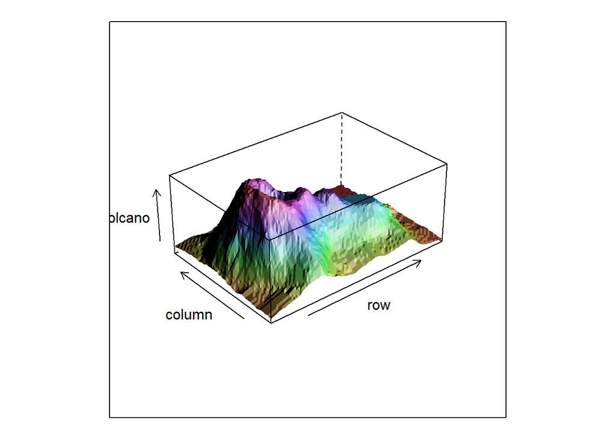

```r
# Examples of 3 dimensional scatter plots
## volcano  ## 87 x 61 matrix
wireframe(volcano, shade = TRUE,
          aspect = c(61/87, 0.4),
          light.source = c(10,0,10))
```

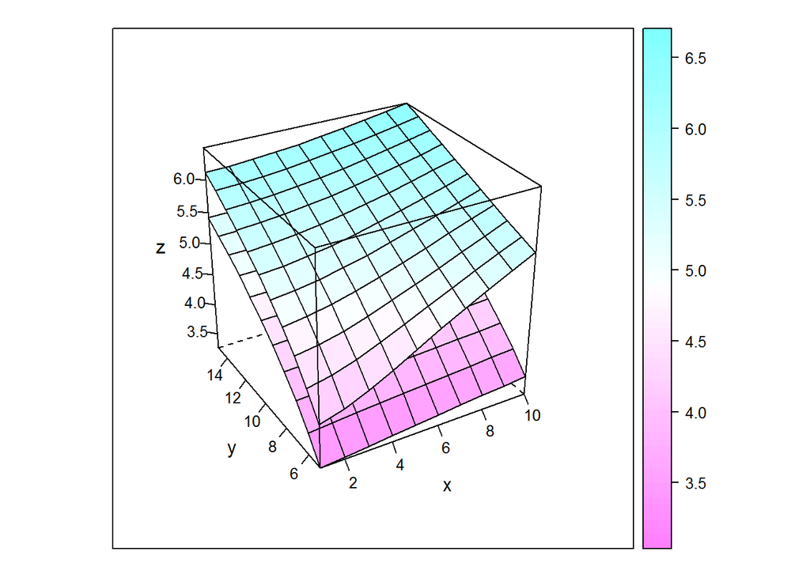

```r
#-------------------------------------------------------------------------------------------
# Wire Frame
g <- expand.grid(x = 1:10, y = 5:15, gr = 1:2)
g$z <- log((g$x^g$g + g$y^2) * g$gr)
wireframe(z ~ x * y, data = g, groups = gr,
          scales = list(arrows = FALSE),
          drape = TRUE, colorkey = TRUE,
          screen = list(z = 30, x = -60))
```

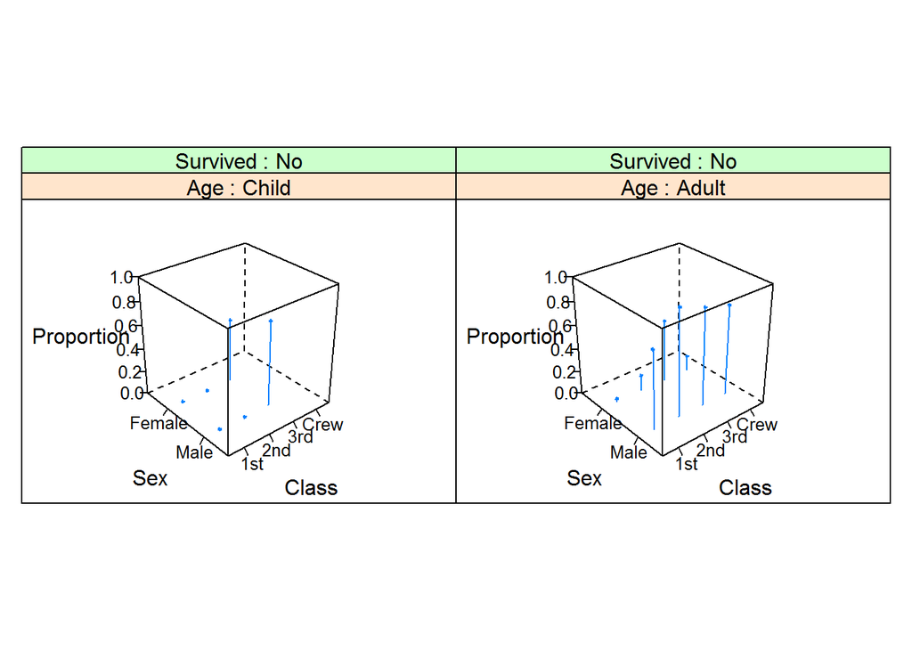

```r
#---------------------------------------------------------------------------------
## cloud.table
cloud(prop.table(Titanic, margin = 1:3),
      type = c("p", "h"), strip = strip.custom(strip.names = TRUE),
      scales = list(arrows = FALSE, distance = 2), panel.aspect = 0.7,
      zlab = "Proportion")[, 1]
```

```r
#----------------------------------------------------------------------------------
```

# GGPLOT2 GRAPHICS

ggplot is the third major plotting system for R.It is based on Leland Wilkinson’s grammar of graphics. Plots are built in layers.

Some useful websites are: http://www.cs.uic.edu/~wilkinson/TheGrammarOfGraphics/GOG.html http://ggplot2.org/ http://docs.ggplot2.org/current/ http://www.cookbook-r.com/Graphs/

Here we illustrate building up a multi-layer plot

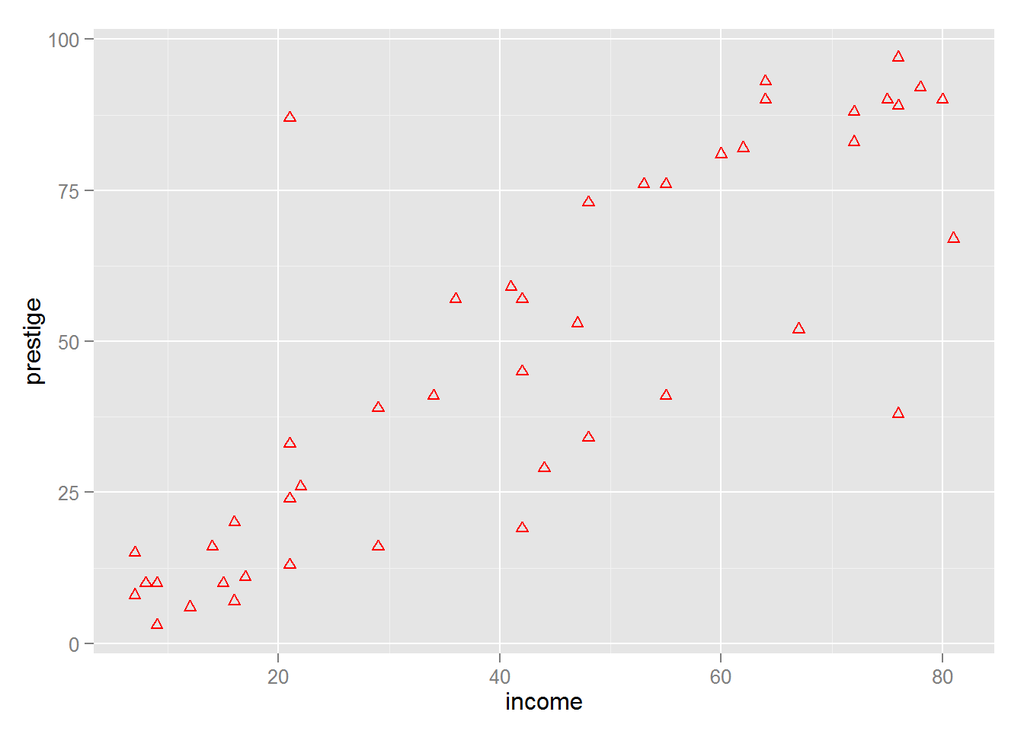

```r
library(ggplot2)
# Scatter plot
p <- ggplot(Duncan, aes(income, prestige))                      # data to be plotted
# p     # This will produce an error since no layers are defined
layer1 <- geom_point(shape = 2,colour="red")                    # First layer specifies kind of plot
p + layer1
```

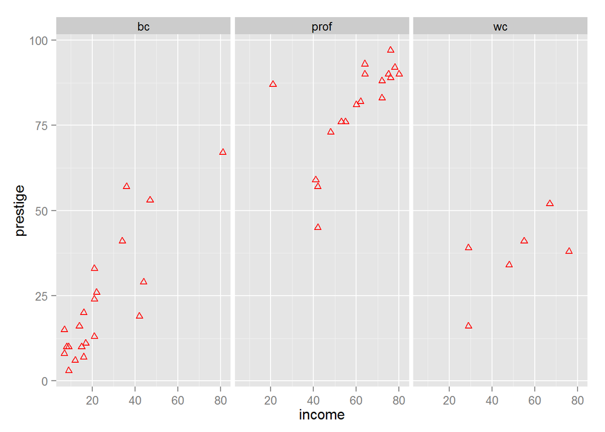

```r
layer2 <- facet_wrap(~ type)                                            # Second layer builds facet plot
p + layer1 + layer2
```

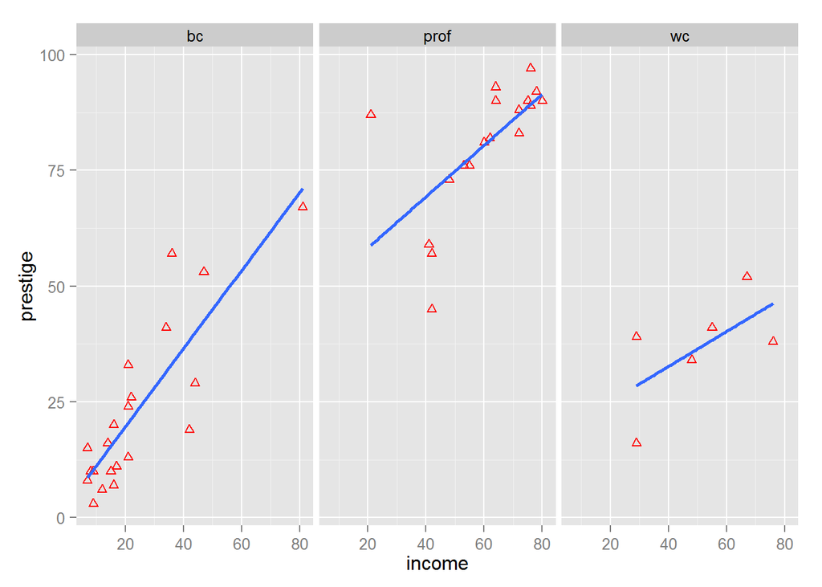

```r
layer3 <- geom_smooth(aes(group=type),method="lm",size=1,se=F)  # Third layer add a regression line
p + layer1 + layer2 + layer3
```

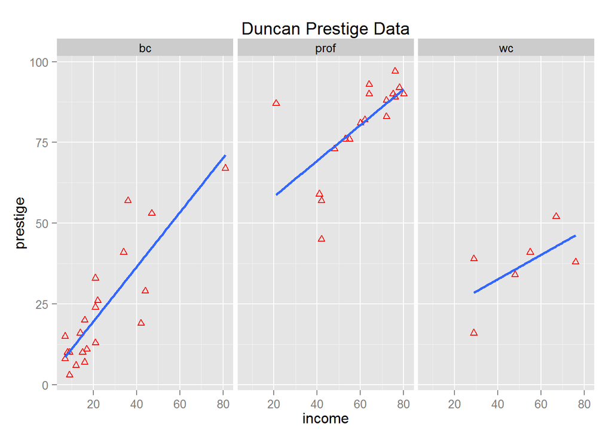

```r
layer4 <- ggtitle("Duncan Prestige Data")                          # Fourth layer add a title
p + layer1 + layer2 + layer3 + layer4
```

## Basic ggplot2 Histogram

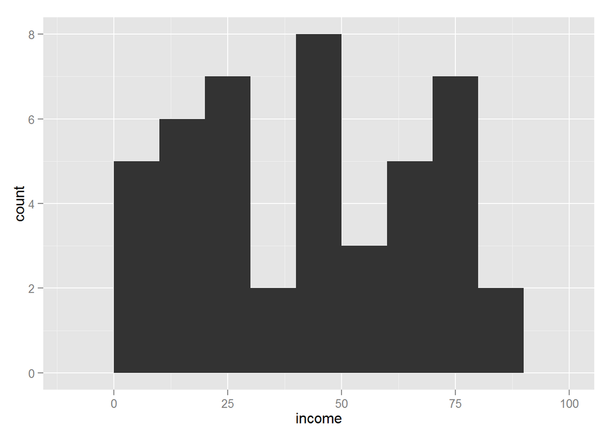

```r
p <- ggplot(Duncan,aes(income))
p + geom_histogram(binwidth=10)
```

## ggplot Scatterplot

```
## geom_smooth: method="auto" and size of largest group is <1000, so using loess. Use 'method = x' to change the smoothing method.
```

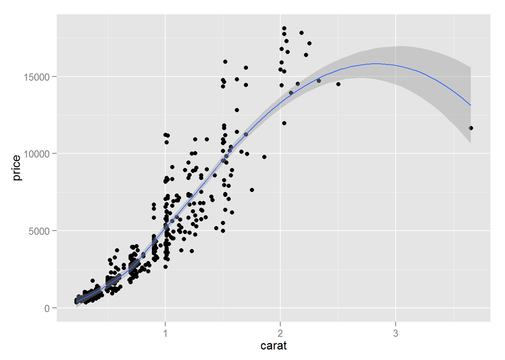

```r
set.seed(1410) # Make the sample reproducible
dsmall <- diamonds[sample(nrow(diamonds), 500), ]
p <- ggplot(dsmall, aes(carat, price))
p + geom_point() + stat_smooth()
```

```r
# Same plot with alternate "simple" plot function qplot
```

## qplot examples

The ggplot2 package also has a function called qplot which is often simpler to use However, it has a different syntax than the ggplot function.

```
## geom_smooth: method="auto" and size of largest group is >=1000, so using gam with formula: y ~ s(x, bs = "cs"). Use 'method = x' to change the smoothing method.
```

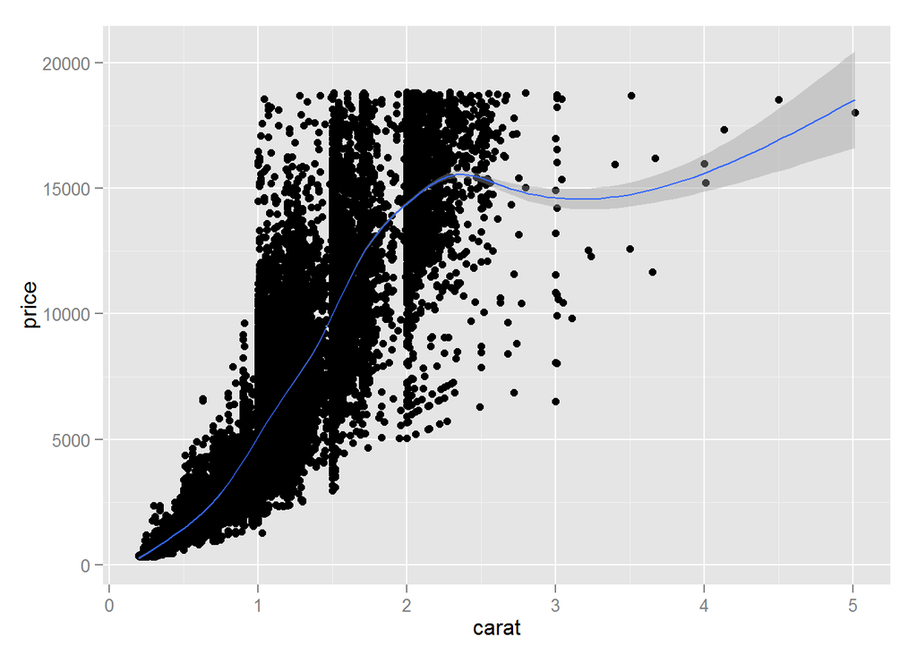

```r
qplot(carat, price, data = diamonds, geom = c("point", "smooth"))
```

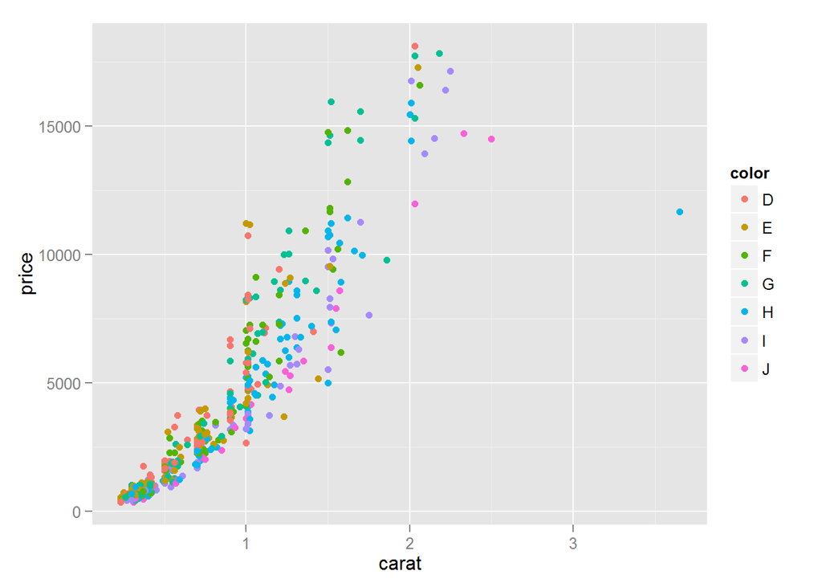

```r
# Mapping point colour to diamond colour (left), and point shape to cut
# quality (right).
qplot(carat, price, data = dsmall, colour = color)
```

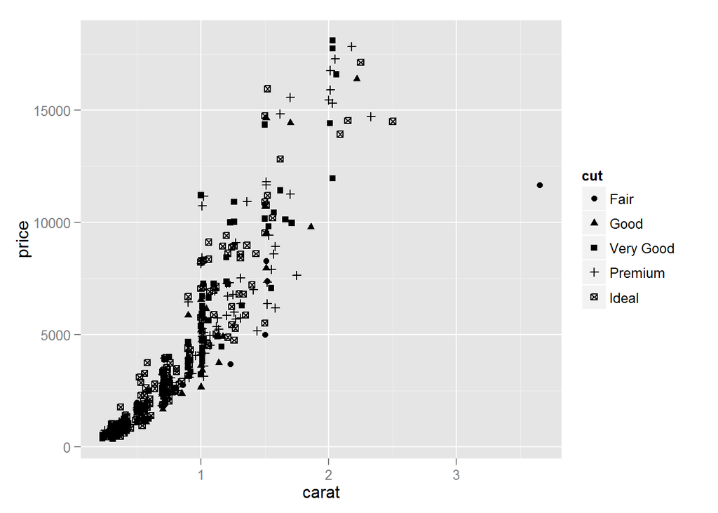

```r
qplot(carat, price, data = dsmall, shape = cut)
```

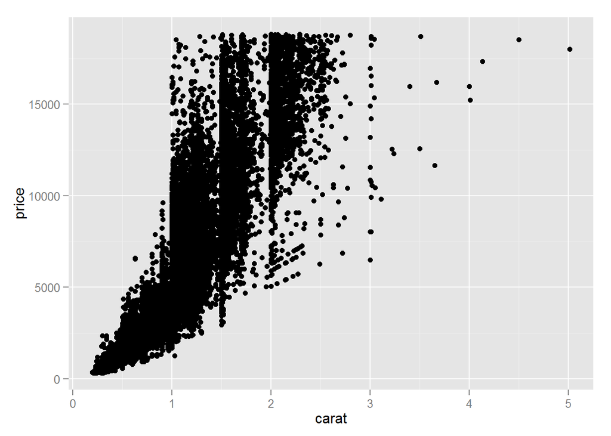

```r
#
# Reducing the alpha value from 1/10 (left) to 1/100 (middle) to 1/200
# (right) makes it possible to see where the bulk of the points lie.
qplot(carat, price, data = diamonds)
```

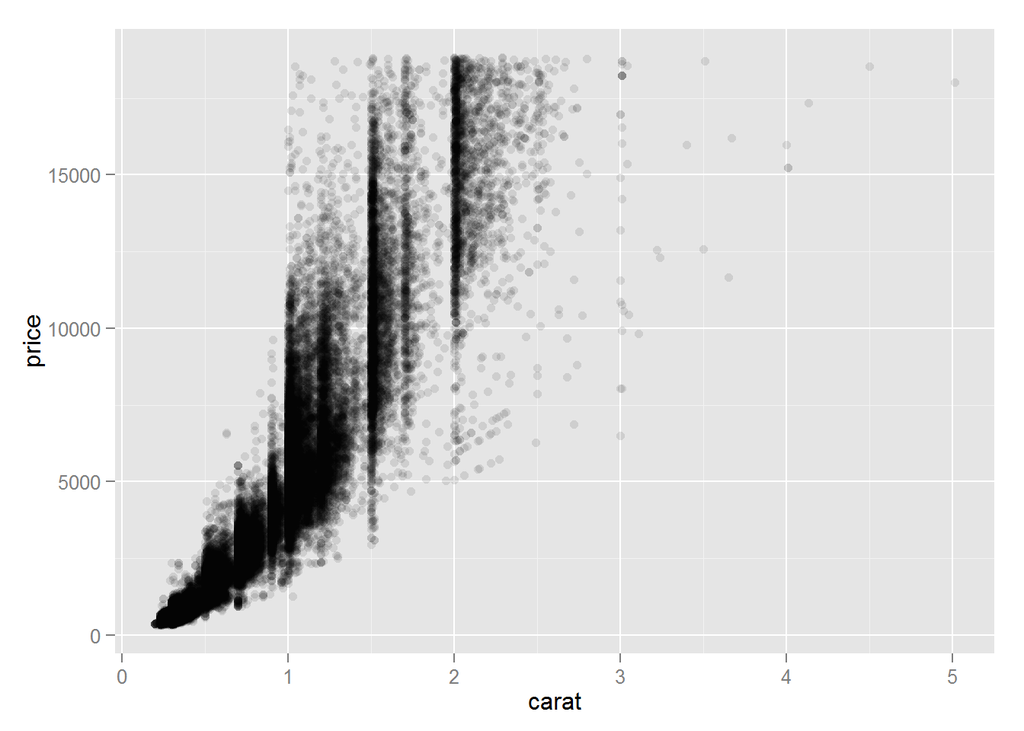

```r
qplot(carat, price, data = diamonds, alpha = I(1/10))
```

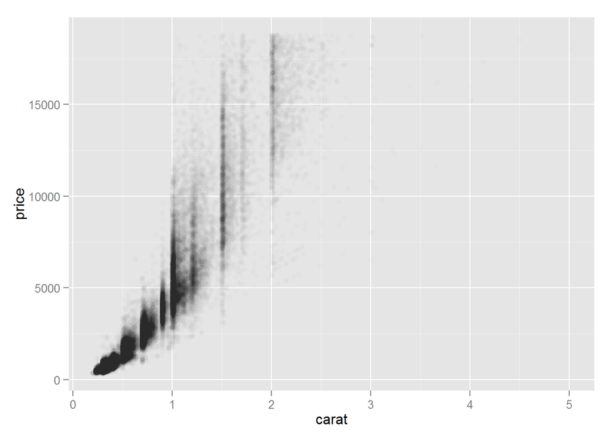

```r
qplot(carat, price, data = diamonds, alpha = I(1/100))
```

```
## geom_smooth: method="auto" and size of largest group is <1000, so using loess. Use 'method = x' to change the smoothing method.
```

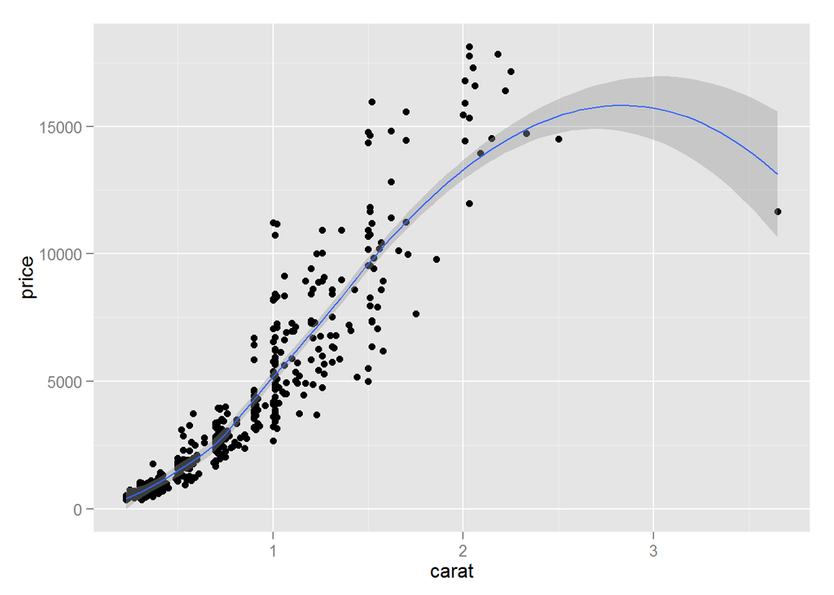

```r
#
# Smooth curves add to scatterplots of carat vs.\ price. The dsmall
# dataset (1st) and the full dataset (2nd).
qplot(carat, price, data = dsmall, geom = c("point", "smooth"))
```

```r
#
```